## Investigate the distribution of your friends birth months and days.

How many people have the same birthday as you?

Which month contains the most number of birthdays?

How many birthdays are in each month?

Which day of the year has the most number of birthdays?

Do you have at least 365 friends that have birthdays on everyday of the year?

1. You’ll need to export your Facebooks friends’ birthdays to a csv file. You may need to create a calendar of your Facebook friends’ birthdays in a program like Outlook or Gmail and then export the calendar as a csv file.
2. Once you load the data into R Studio, you can use the strptime() function to extract the birth months and birth days. We recommend looking up the documentation for the function and finding examples online.
3. [Download Your Friends’ Birthdays from Facebook](https://www.facebook.com/help/152652248136178/)
4. [Date Formats in R](https://www.r-bloggers.com/date-formats-in-r/)
5. [Export a Google Calendar](https://support.google.com/calendar/answer/37111?hl=en)
6. [Google Calendar to Excel: Free Trial](https://www.gcal2excel.com/)

```r
bdays <- read.csv("fb_bdays.csv")
bdays$bday <- as.Date(bdays$bday )
```

## Including Plots

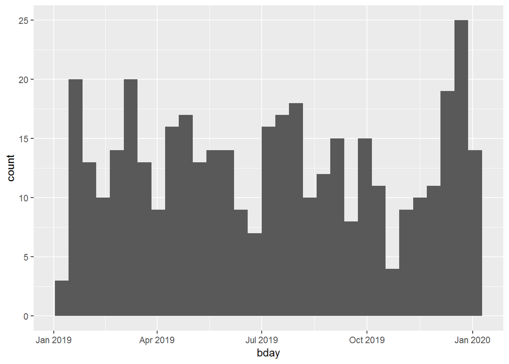

```r
library(ggplot2)
ggplot(aes(x = bday), data = bdays) +
  geom_histogram(binwidth = 12)
```

### Histogram of Birthdays by Month

### How many birthdays are in each month?

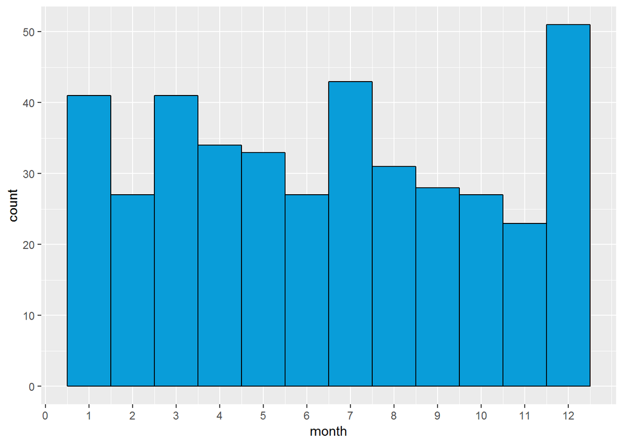

```r
library(ggplot2)
ggplot(aes(x = month), data = bdays) +
  geom_histogram(color = 'black', fill = '#099DD9', binwidth = 1) +
  scale_x_continuous(breaks = 0:12)
```

```r
table(bdays$month)
```

```
##
##  1  2  3  4  5  6  7  8  9 10 11 12
## 41 27 41 34 33 27 43 31 28 27 23 51
```

We can see that the spike of the distribution is in December with 51 birthdays.

### Histogram of Birthdays by Days

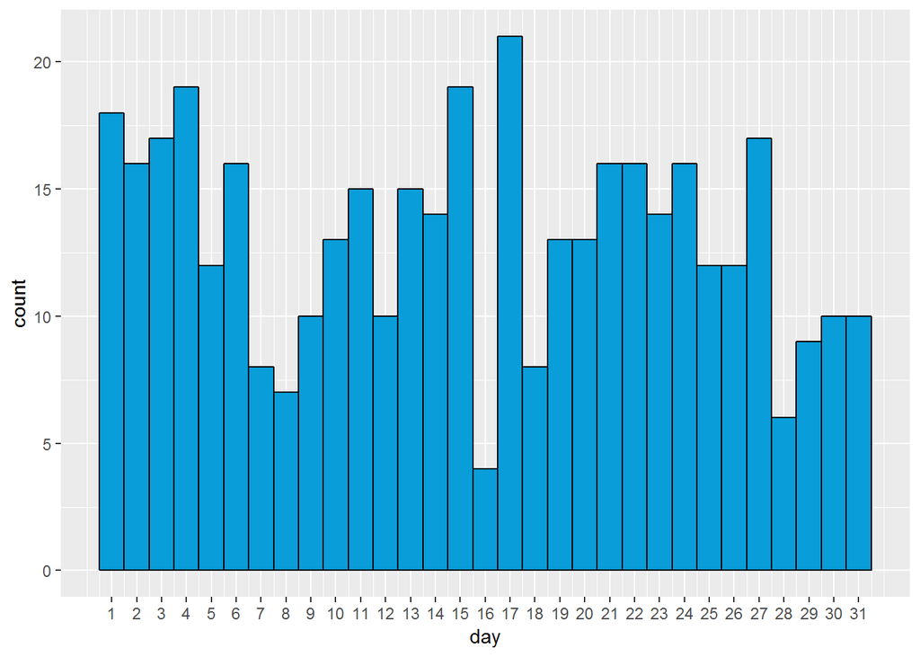

```r
ggplot(aes(x = day), data = bdays) +
  geom_histogram(color = 'black', fill = '#099DD9', binwidth = 1) +
  scale_x_continuous(breaks = 1:31)
```

From the above histogram we can see that 17 is the day with highest frequency, while the 16th day has the lowest frequency.

### Histogram of Birthdays by Days and Months

Let’s break the the histogram into twelve histograms, one for each month of the year.

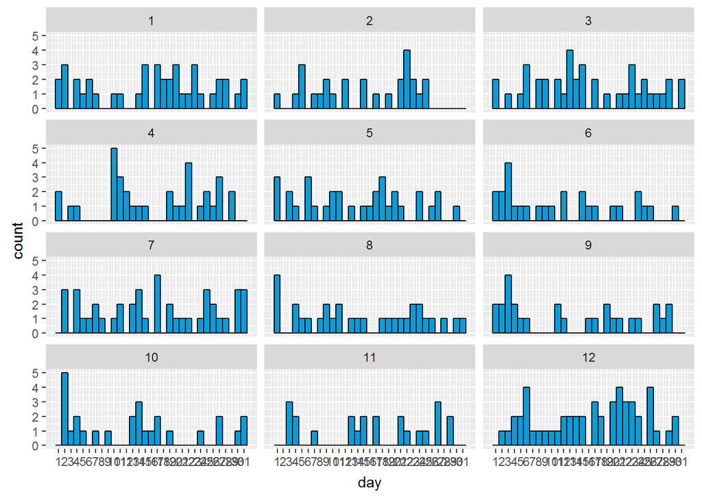

```r
ggplot(aes(x = day), data = bdays) +
  geom_histogram(color = 'black', fill = '#099DD9', binwidth = 1) +
  scale_x_continuous(breaks = 1:31) +
  facet_wrap(~month, ncol = 3)
```

```r
ggsave('monthHistogram.png')
```

### How many people have the same birthday as you?

```r
dim(subset(bdays, bdays$bday == "2019-03-25" & bdays$name != "Ana Hristian"))[1]
```

```
## [1] 1
```

So, only one friend has the same birthday as me.

### Which month contains the most number of birthdays?

December

# Which day of the year has the most number of birthdays?

```r
table(bdays$day)
```

```
##
##  1  2  3  4  5  6  7  8  9 10 11 12 13 14 15 16 17 18 19 20 21 22 23 24 25
## 18 16 17 19 12 16  8  7 10 13 15 10 15 14 19  4 21  8 13 13 16 16 14 16 12
## 26 27 28 29 30 31
## 12 17  6  9 10 10
```